# Machine Learning Notes

Lastly, we do a bit of space exploration using lambda of 1:

```r
for (alphaSize in c(0.3, 0.6, 1, 1.5)) {
    for (batchSize in c(10, 25, 50, 100)) {

        vecPass=c(as.vector(bpThetaOne), as.vector(bpThetaTwo))

        # Each run will cycle through the data (3500 records) 10 times
        testMiniBatch(vecUse=vecPass, nInputLayer=nInputLayer, nHiddenNodes=nHiddenNodes,
                      nFinalLabels=nFinalLabels, trainX=mtxX[idxTrain, ],
                      trainY=mtxY[idxTrain, ,drop=FALSE],
                      cvX=mtxX[-idxTrain, ], cvY=mtxY[-idxTrain, ,drop=FALSE],
                      useLambda=1, useAlpha=alphaSize, nBatch=batchSize,
                      nRuns=35000/batchSize, nPerSave=1000, cmFull=FALSE, useSeed=1606131243
                      )

    }
}
```

```
## [1] "Setting seed to: 1606131243"
##    user  system elapsed
##    6.77    0.01    6.78
```

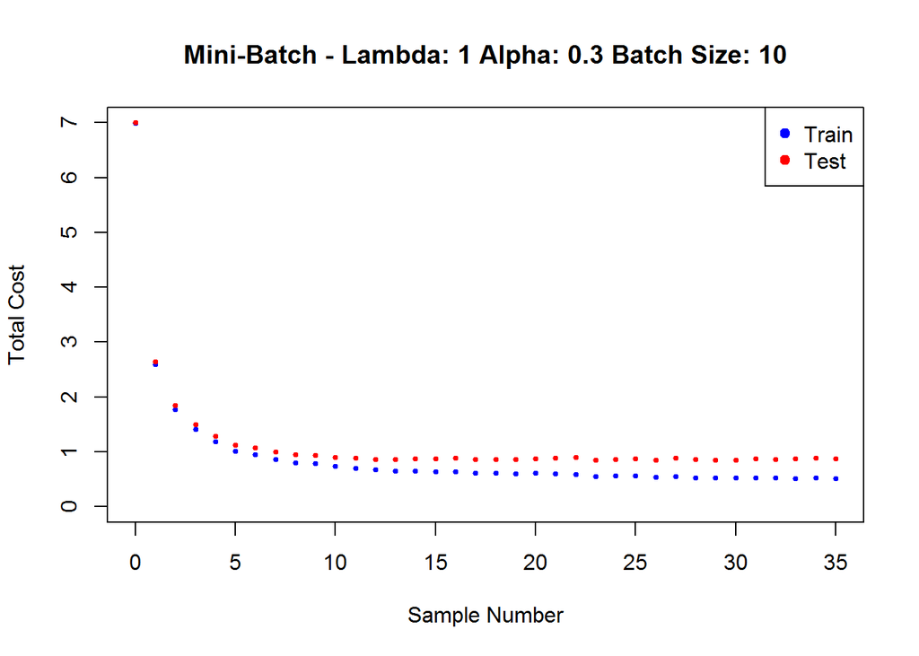

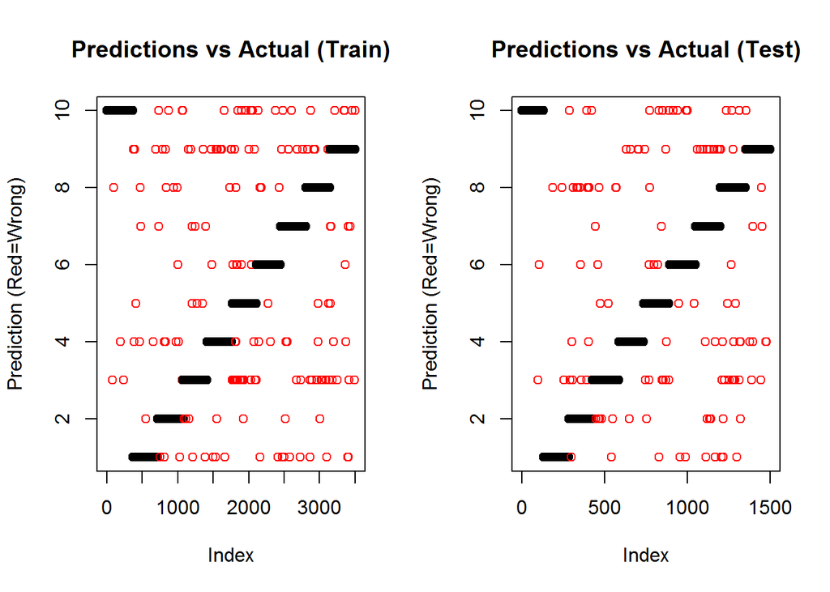

```
##       Accuracy          Kappa  AccuracyLower  AccuracyUpper   AccuracyNull
##      0.9511429      0.9457101      0.9434724      0.9580479      0.1051429
## AccuracyPValue  McnemarPValue
##      0.0000000            NaN
##       Accuracy          Kappa  AccuracyLower  AccuracyUpper   AccuracyNull
##      0.9193333      0.9103509      0.9043826      0.9326163      0.1066667
## AccuracyPValue  McnemarPValue
##      0.0000000            NaN
## [1] "Setting seed to: 1606131243"
##    user  system elapsed
##    5.02    0.00    5.04
```

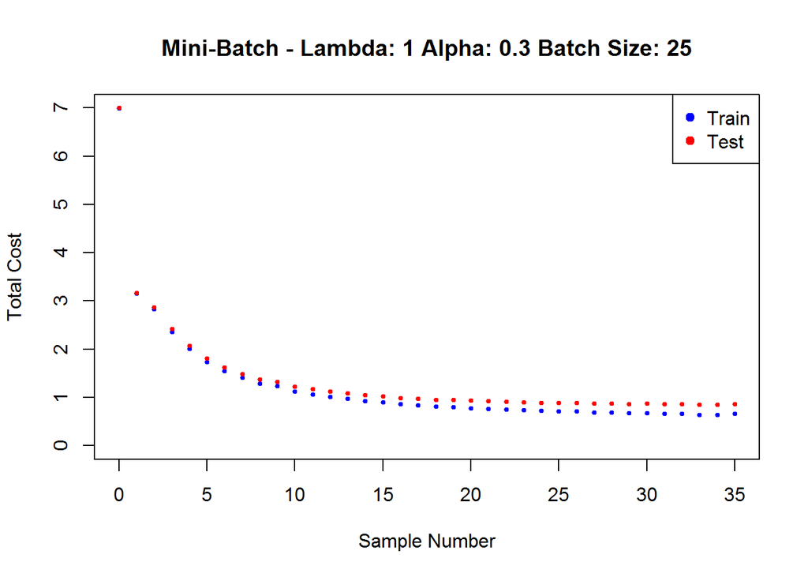

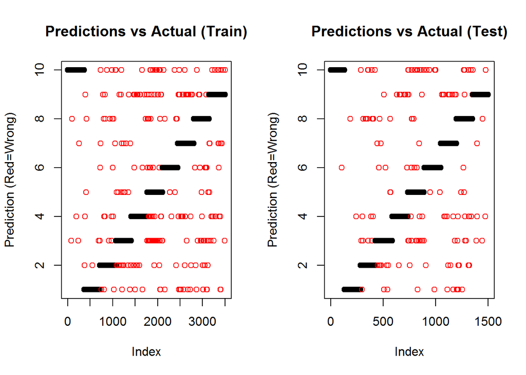

```
##       Accuracy          Kappa  AccuracyLower  AccuracyUpper   AccuracyNull
##      0.9248571      0.9164993      0.9156208      0.9333760      0.1051429
## AccuracyPValue  McnemarPValue
##      0.0000000            NaN
##       Accuracy          Kappa  AccuracyLower  AccuracyUpper   AccuracyNull
##      0.9040000      0.8933259      0.8879575      0.9184393      0.1066667
## AccuracyPValue  McnemarPValue
##      0.0000000            NaN
## [1] "Setting seed to: 1606131243"
##    user  system elapsed
##    4.64    0.01    4.68
```

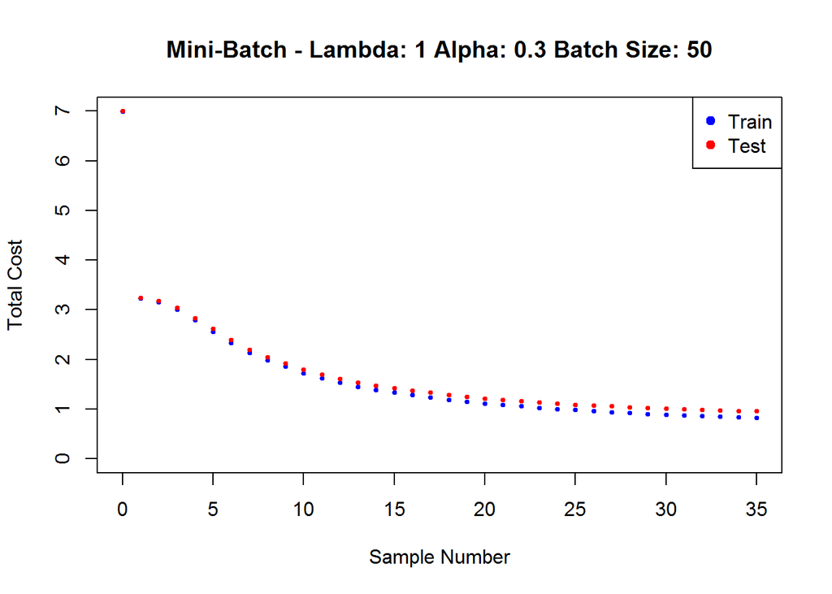

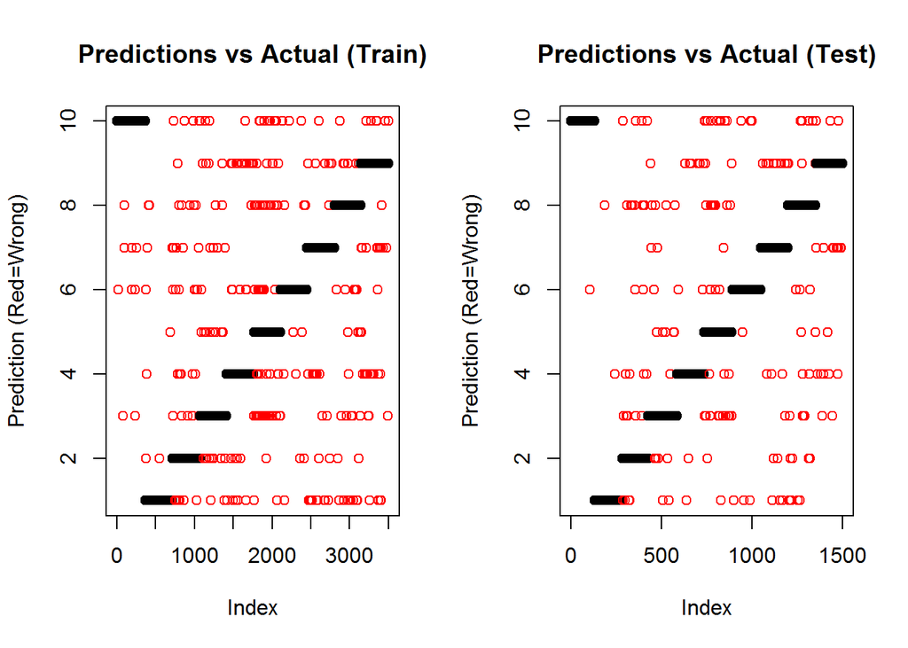

```
##       Accuracy          Kappa  AccuracyLower  AccuracyUpper   AccuracyNull
##      0.9077143      0.8974532      0.8976391      0.9171022      0.1051429
## AccuracyPValue  McnemarPValue
##      0.0000000            NaN
##       Accuracy          Kappa  AccuracyLower  AccuracyUpper   AccuracyNull
##      0.8846667      0.8718281      0.8674106      0.9003997      0.1066667
## AccuracyPValue  McnemarPValue
##      0.0000000            NaN
## [1] "Setting seed to: 1606131243"
##    user  system elapsed
##    4.26    0.04    4.31
```

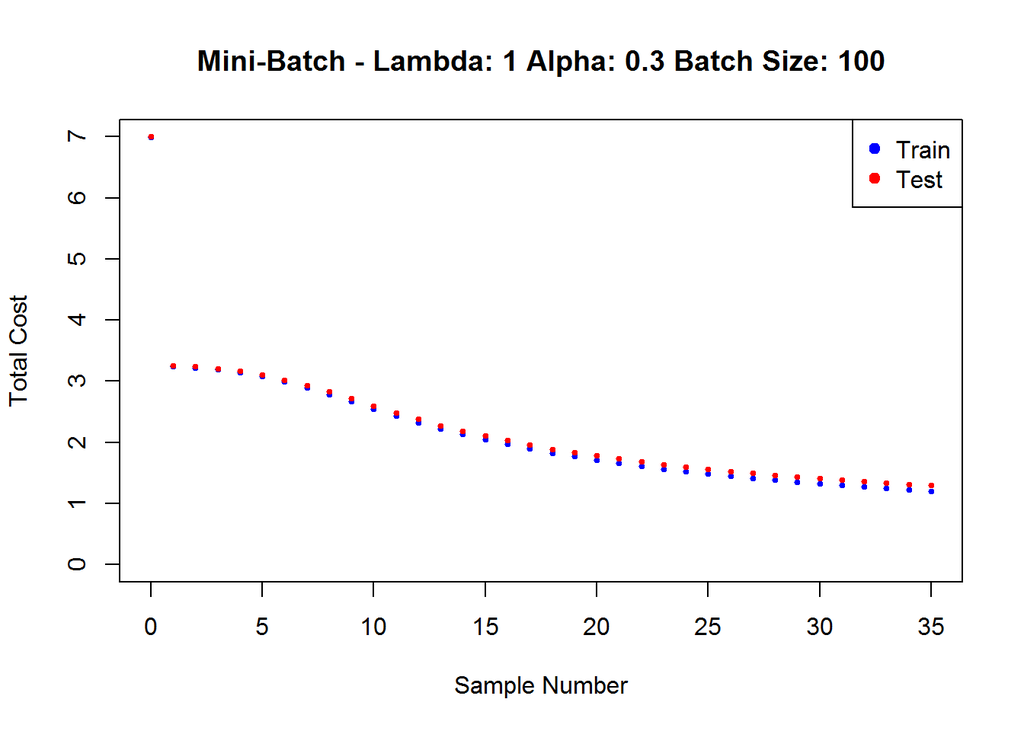

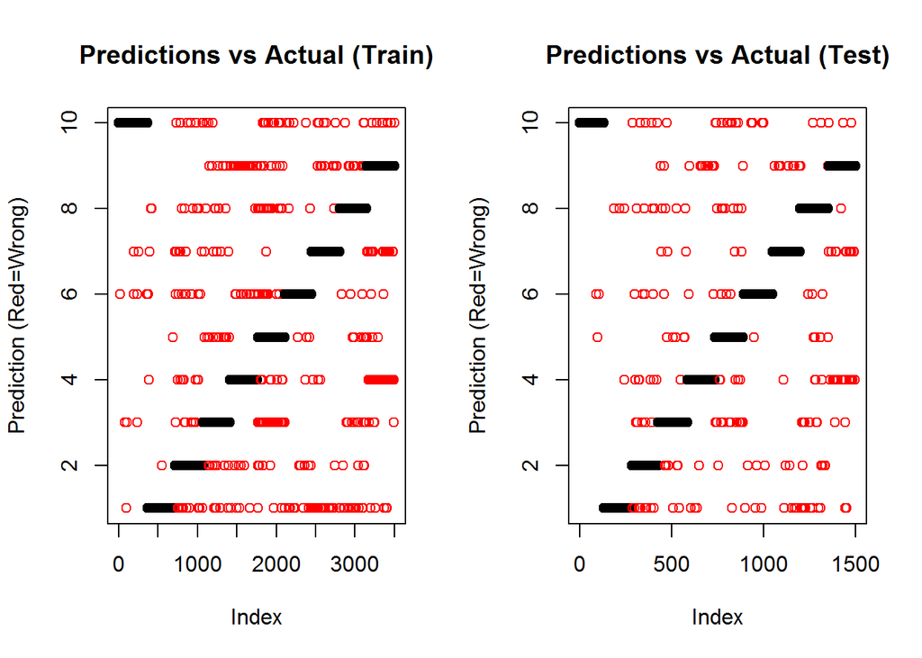

```
##       Accuracy          Kappa  AccuracyLower  AccuracyUpper   AccuracyNull
##      0.8628571      0.8476099      0.8510146      0.8740899      0.1051429
## AccuracyPValue  McnemarPValue
##      0.0000000            NaN
##       Accuracy          Kappa  AccuracyLower  AccuracyUpper   AccuracyNull
##      0.8460000      0.8288538      0.8267256      0.8639084      0.1066667
## AccuracyPValue  McnemarPValue
##      0.0000000            NaN
## [1] "Setting seed to: 1606131243"
##    user  system elapsed
##    6.83    0.00    6.87
```

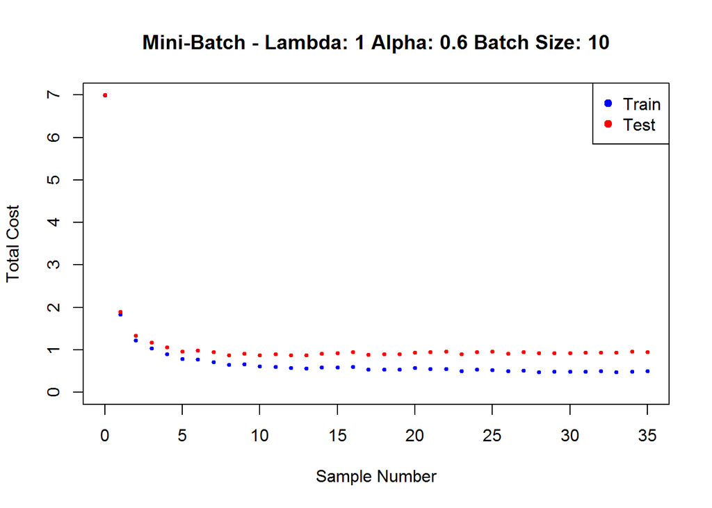

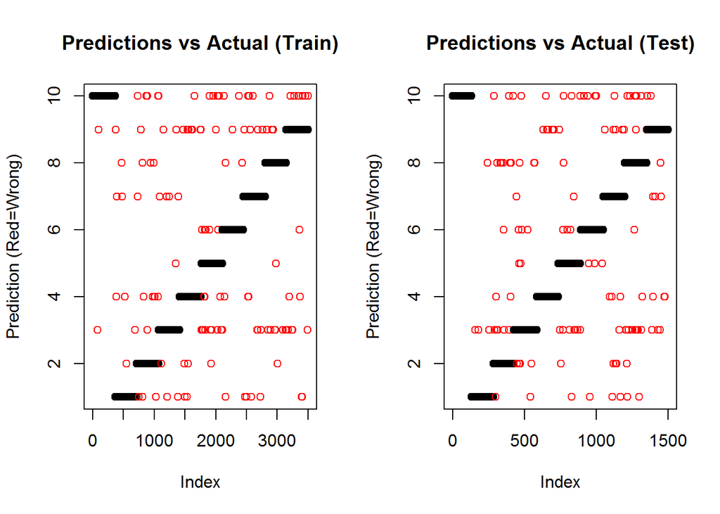

```
##       Accuracy          Kappa  AccuracyLower  AccuracyUpper   AccuracyNull
##      0.9605714      0.9561868      0.9535851      0.9667743      0.1051429
## AccuracyPValue  McnemarPValue
##      0.0000000            NaN
##       Accuracy          Kappa  AccuracyLower  AccuracyUpper   AccuracyNull
##      0.9200000      0.9110944      0.9050998      0.9332296      0.1066667
## AccuracyPValue  McnemarPValue
##      0.0000000            NaN
## [1] "Setting seed to: 1606131243"
##    user  system elapsed
##    5.04    0.00    5.04
```

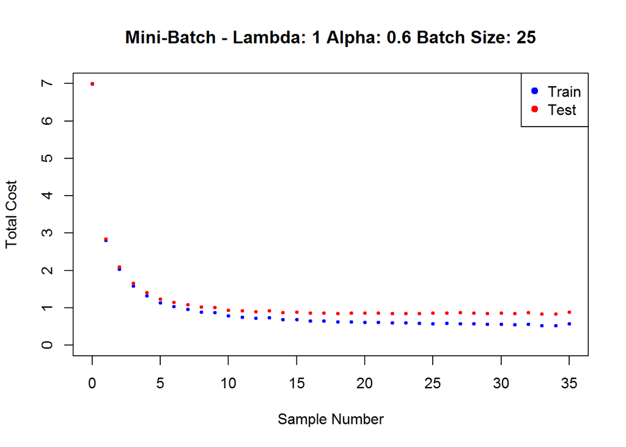

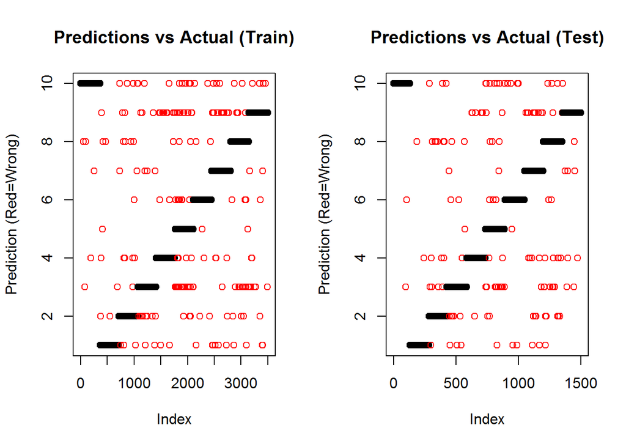

```
##       Accuracy          Kappa  AccuracyLower  AccuracyUpper   AccuracyNull
##      0.9380000      0.9311045      0.9294952      0.9457637      0.1051429
## AccuracyPValue  McnemarPValue
##      0.0000000            NaN
##       Accuracy          Kappa  AccuracyLower  AccuracyUpper   AccuracyNull
##      0.9093333      0.8992431      0.8936561      0.9233850      0.1066667
## AccuracyPValue  McnemarPValue
##      0.0000000            NaN
## [1] "Setting seed to: 1606131243"
##    user  system elapsed
##    4.40    0.08    4.48
```

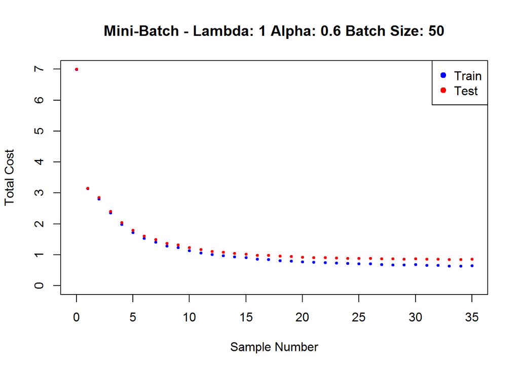

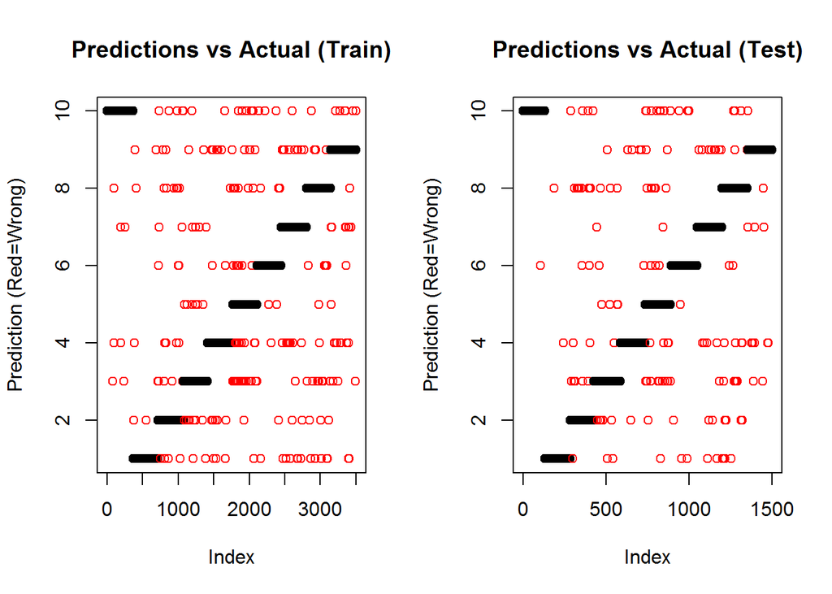

```
##       Accuracy          Kappa  AccuracyLower  AccuracyUpper   AccuracyNull
##      0.9274286      0.9193590      0.9183286      0.9358065      0.1051429
## AccuracyPValue  McnemarPValue
##      0.0000000            NaN
##       Accuracy          Kappa  AccuracyLower  AccuracyUpper   AccuracyNull
##      0.9020000      0.8910909      0.8858242      0.9165809      0.1066667
## AccuracyPValue  McnemarPValue
##      0.0000000            NaN
## [1] "Setting seed to: 1606131243"
##    user  system elapsed
##    4.22    0.03    4.26
```

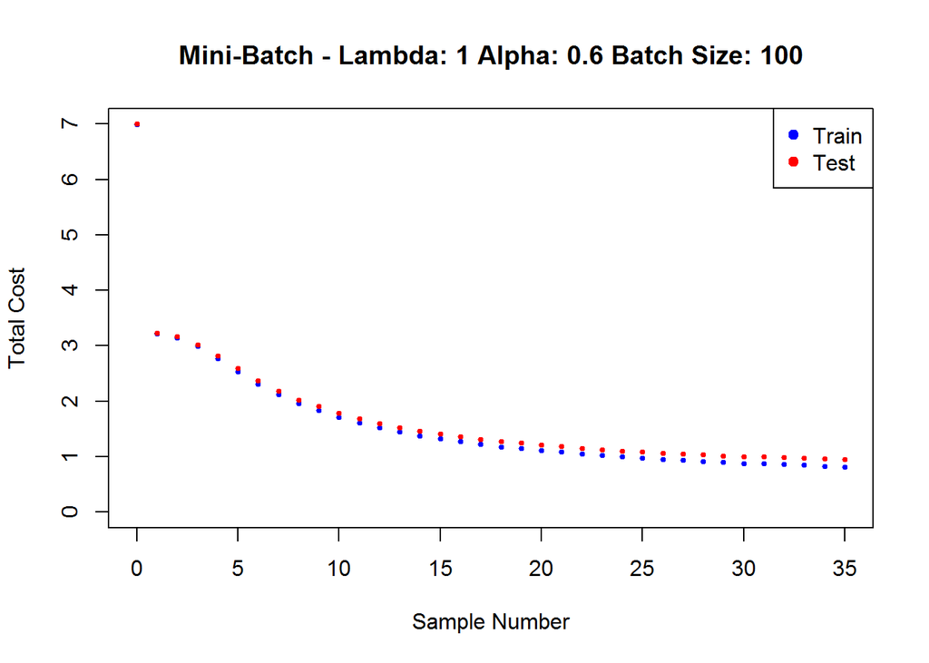

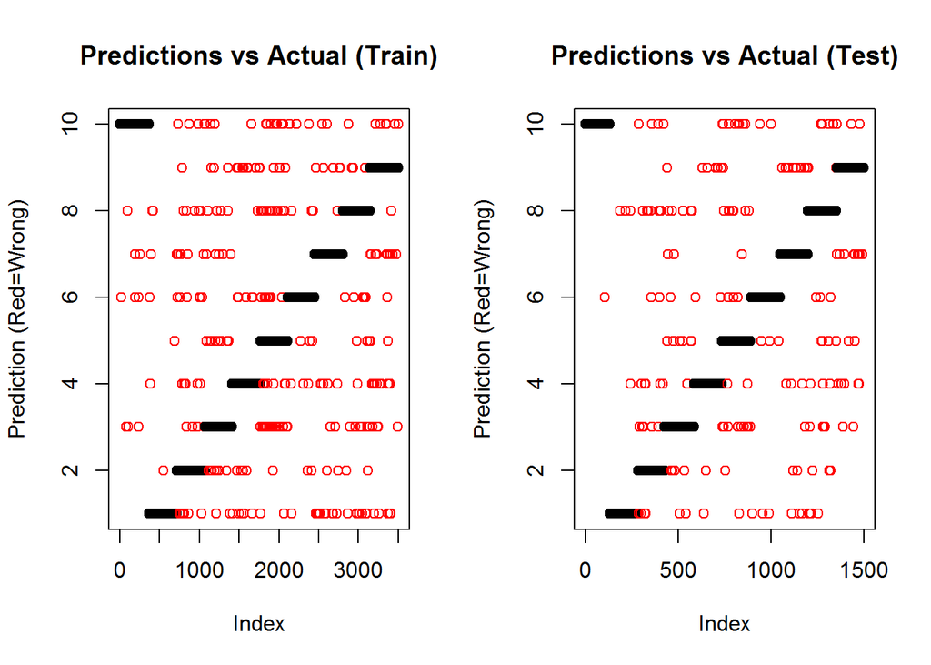

```
##       Accuracy          Kappa  AccuracyLower  AccuracyUpper   AccuracyNull
##      0.9105714      0.9006291      0.9006283      0.9198223      0.1051429
## AccuracyPValue  McnemarPValue
##      0.0000000            NaN
##       Accuracy          Kappa  AccuracyLower  AccuracyUpper   AccuracyNull
##      0.8826667      0.8696000      0.8652938      0.8985246      0.1066667
## AccuracyPValue  McnemarPValue
##      0.0000000            NaN
## [1] "Setting seed to: 1606131243"
##    user  system elapsed
##    6.86    0.03    6.91
```

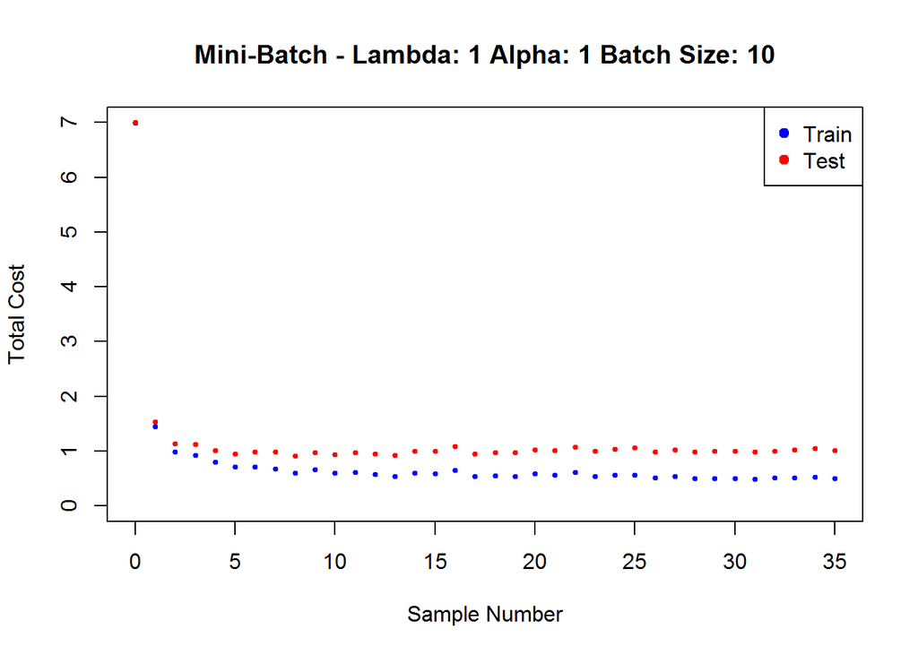

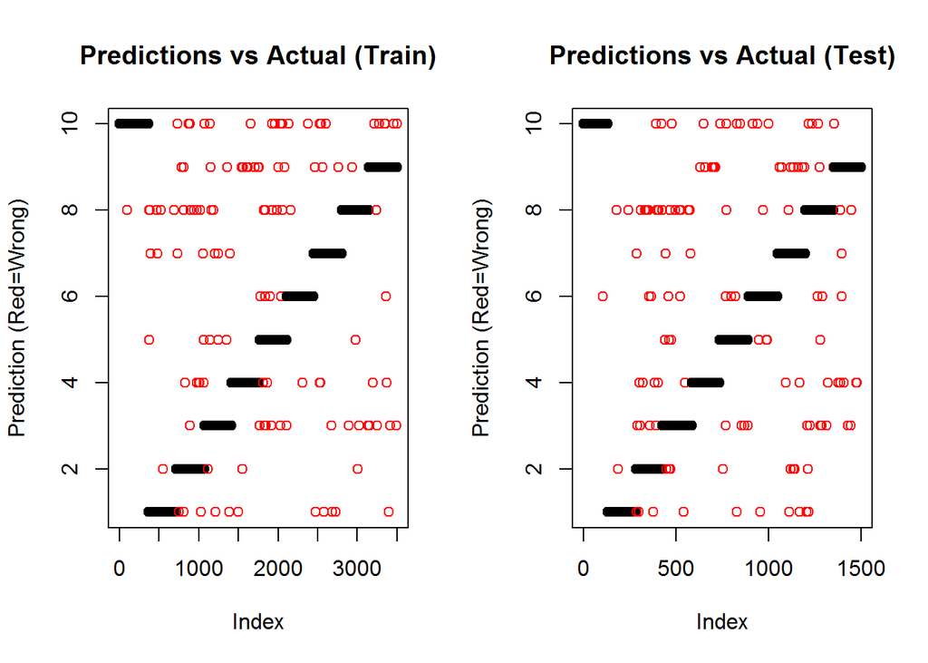

```
##       Accuracy          Kappa  AccuracyLower  AccuracyUpper   AccuracyNull
##      0.9645714      0.9606319      0.9579036      0.9704478      0.1051429
## AccuracyPValue  McnemarPValue
##      0.0000000            NaN
##       Accuracy          Kappa  AccuracyLower  AccuracyUpper   AccuracyNull
##      0.9180000      0.9088648      0.9029490      0.9313888      0.1066667
## AccuracyPValue  McnemarPValue
##      0.0000000            NaN
## [1] "Setting seed to: 1606131243"
##    user  system elapsed
##     5.1     0.0     5.1
```

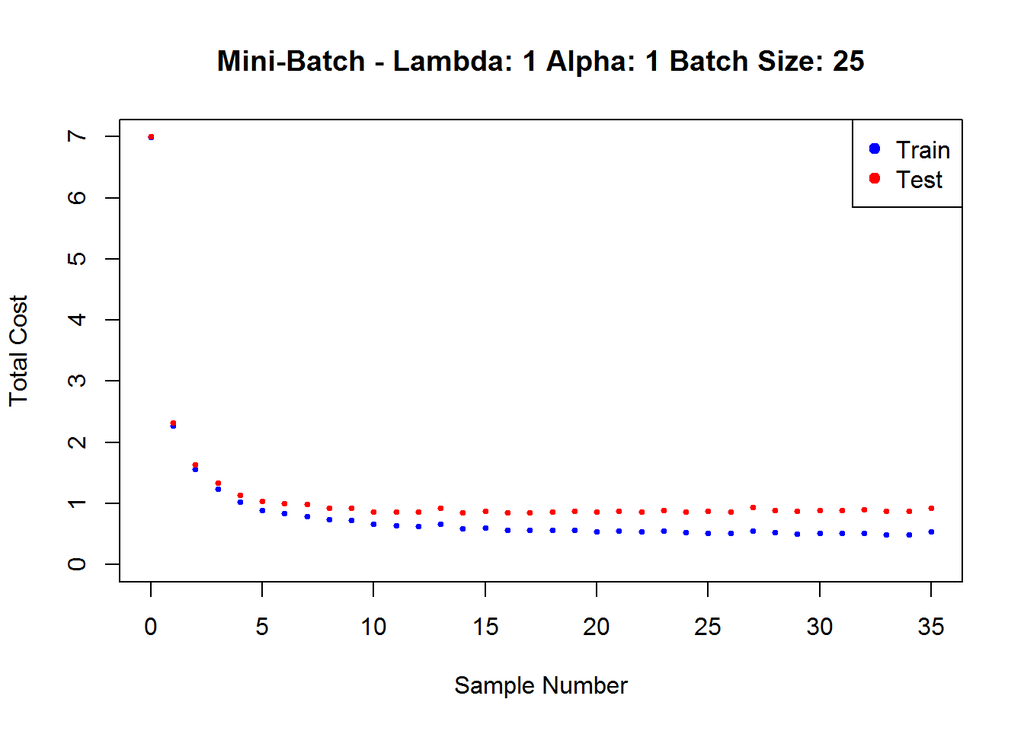

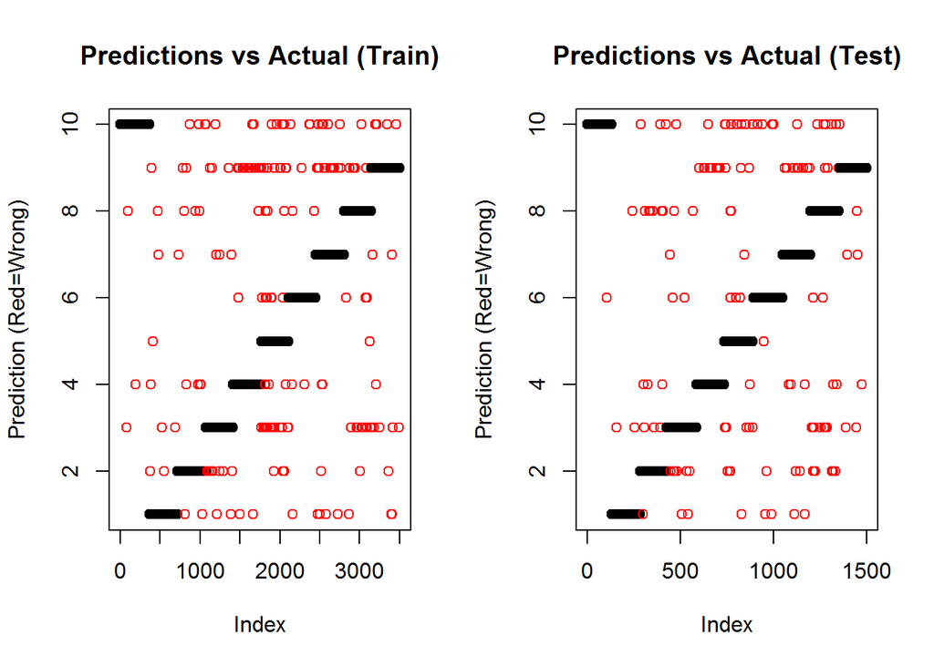

```
##       Accuracy          Kappa  AccuracyLower  AccuracyUpper   AccuracyNull
##      0.9457143      0.9396757      0.9376846      0.9529887      0.1051429
## AccuracyPValue  McnemarPValue
##      0.0000000            NaN
##       Accuracy          Kappa  AccuracyLower  AccuracyUpper   AccuracyNull
##      0.9126667      0.9029603      0.8972253      0.9264685      0.1066667
## AccuracyPValue  McnemarPValue
##      0.0000000            NaN
## [1] "Setting seed to: 1606131243"
##    user  system elapsed
##    4.40    0.00    4.41
```

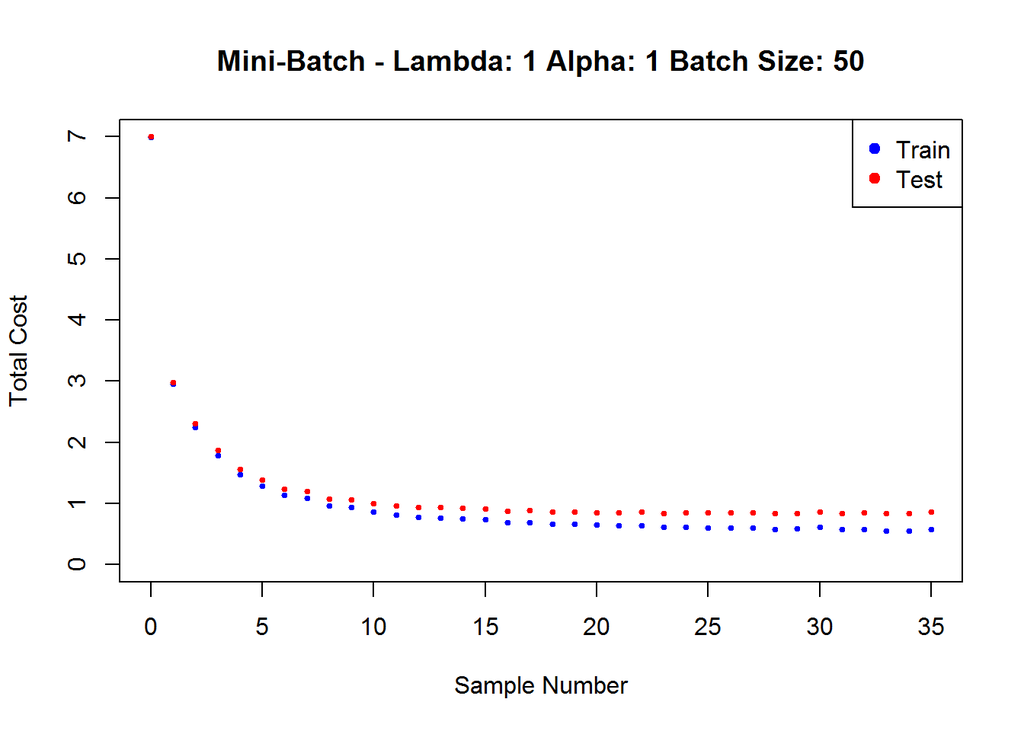

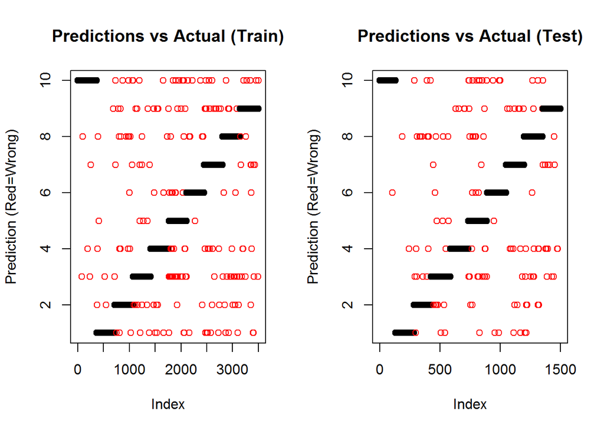

```
##       Accuracy          Kappa  AccuracyLower  AccuracyUpper   AccuracyNull
##      0.9385714      0.9317402      0.9301006      0.9463001      0.1051429
## AccuracyPValue  McnemarPValue
##      0.0000000            NaN
##       Accuracy          Kappa  AccuracyLower  AccuracyUpper   AccuracyNull
##      0.9120000      0.9022043      0.8965110      0.9258523      0.1066667
## AccuracyPValue  McnemarPValue
##      0.0000000            NaN
## [1] "Setting seed to: 1606131243"
##    user  system elapsed
##    4.16    0.01    4.22
```

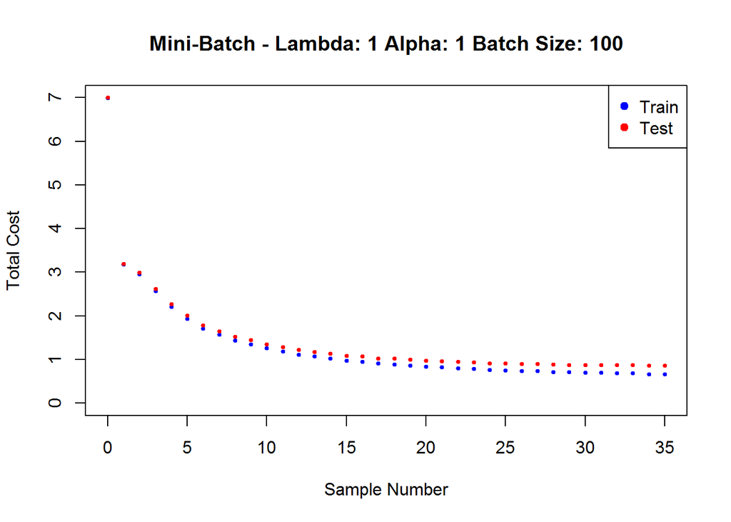

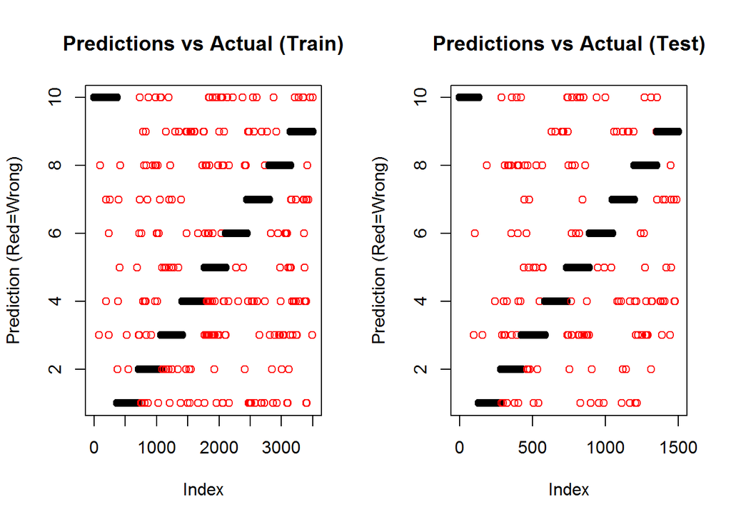

```
##       Accuracy          Kappa  AccuracyLower  AccuracyUpper   AccuracyNull
##      0.9265714      0.9184078      0.9174257      0.9349966      0.1051429
## AccuracyPValue  McnemarPValue
##      0.0000000            NaN
##       Accuracy          Kappa  AccuracyLower  AccuracyUpper   AccuracyNull
##      0.9000000      0.8888563      0.8836928      0.9147207      0.1066667
## AccuracyPValue  McnemarPValue
##      0.0000000            NaN
## [1] "Setting seed to: 1606131243"
##    user  system elapsed
##    7.08    0.00    7.13
```

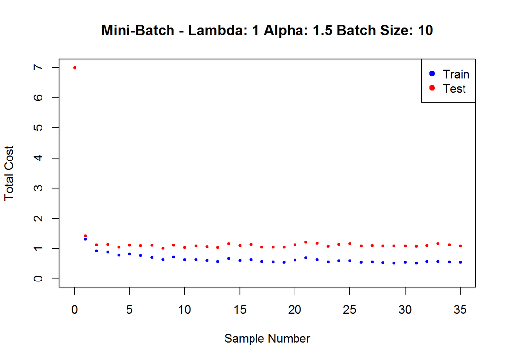

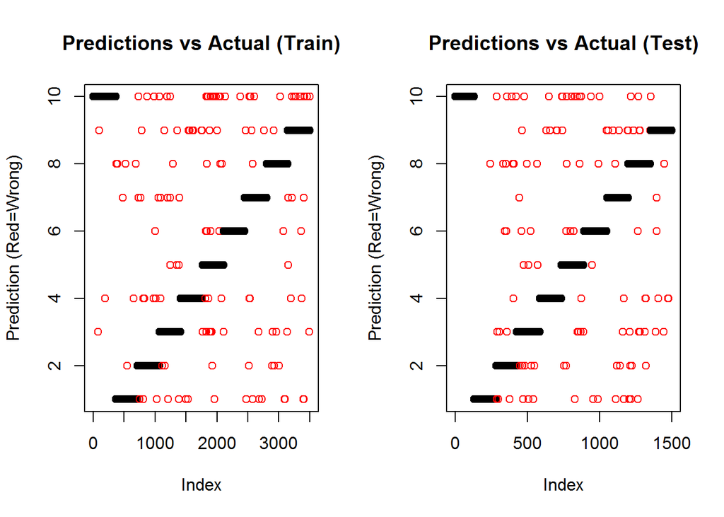

```
##       Accuracy          Kappa  AccuracyLower  AccuracyUpper   AccuracyNull
##      0.9611429      0.9568207      0.9542009      0.9673002      0.1051429
## AccuracyPValue  McnemarPValue
##      0.0000000            NaN
##       Accuracy          Kappa  AccuracyLower  AccuracyUpper   AccuracyNull
##      0.9233333      0.9148062      0.9086900      0.9362918      0.1066667
## AccuracyPValue  McnemarPValue
##      0.0000000            NaN
## [1] "Setting seed to: 1606131243"
##    user  system elapsed
##    5.17    0.00    5.18
```

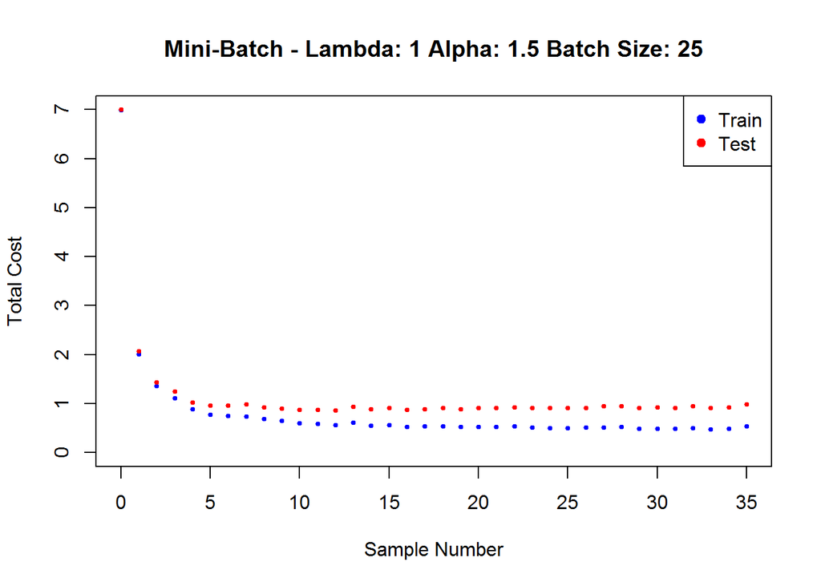

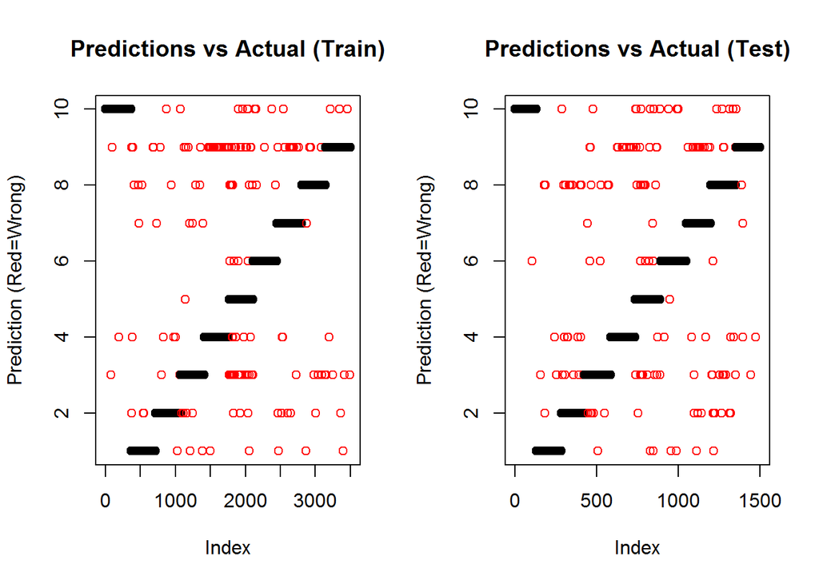

```
##       Accuracy          Kappa  AccuracyLower  AccuracyUpper   AccuracyNull
##      0.9514286      0.9460263      0.9437777      0.9583135      0.1051429
## AccuracyPValue  McnemarPValue
##      0.0000000            NaN
##       Accuracy          Kappa  AccuracyLower  AccuracyUpper   AccuracyNull
##      0.9046667      0.8940601      0.8886691      0.9190583      0.1066667
## AccuracyPValue  McnemarPValue
##      0.0000000            NaN
## [1] "Setting seed to: 1606131243"
##    user  system elapsed
##    4.73    0.00    4.74
```

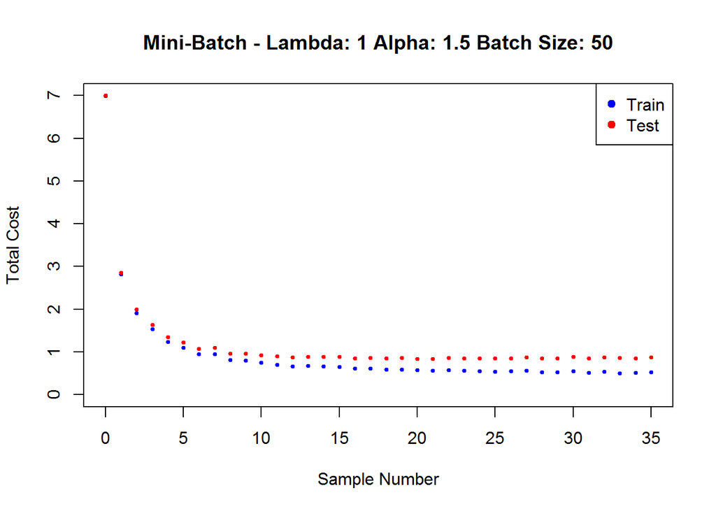

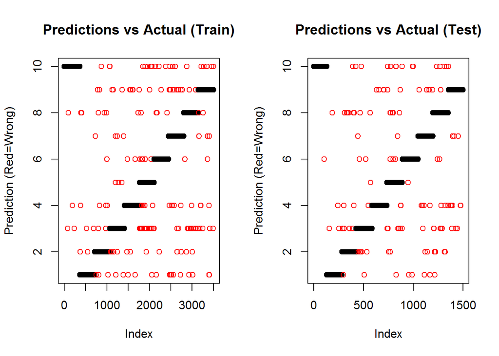

```
##       Accuracy          Kappa  AccuracyLower  AccuracyUpper   AccuracyNull
##      0.9500000      0.9444400      0.9422520      0.9569847      0.1051429
## AccuracyPValue  McnemarPValue
##      0.0000000            NaN
##       Accuracy          Kappa  AccuracyLower  AccuracyUpper   AccuracyNull
##      0.9206667      0.9118340      0.9058172      0.9338426      0.1066667
## AccuracyPValue  McnemarPValue
##      0.0000000            NaN
## [1] "Setting seed to: 1606131243"
##    user  system elapsed
##    4.23    0.00    4.26
```

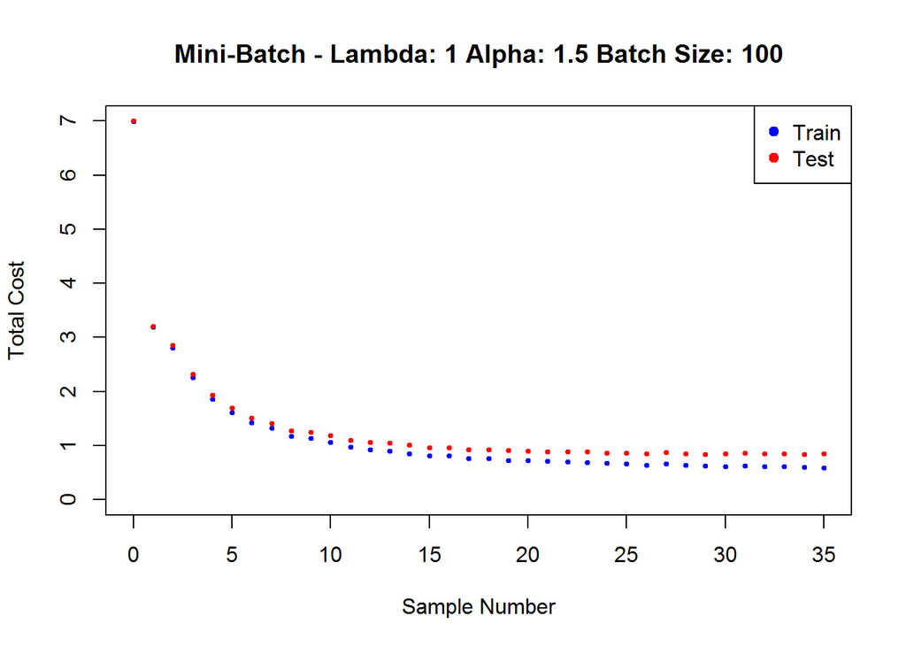

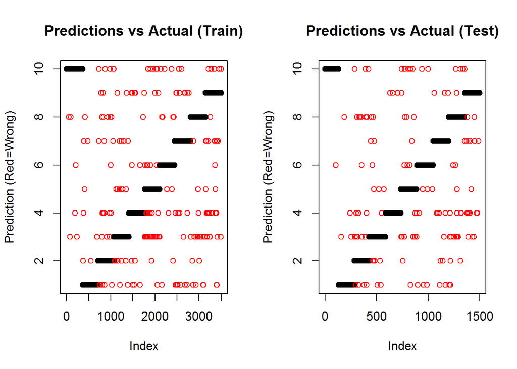

```
##       Accuracy          Kappa  AccuracyLower  AccuracyUpper   AccuracyNull
##      0.9357143      0.9285672      0.9270758      0.9436159      0.1051429
## AccuracyPValue  McnemarPValue
##      0.0000000            NaN
##       Accuracy          Kappa  AccuracyLower  AccuracyUpper   AccuracyNull
##      0.9080000      0.8977474      0.8922301      0.9221500      0.1066667
## AccuracyPValue  McnemarPValue
##      0.0000000            NaN
```

In general, it seems that a larger batch size works better with a slightly larger alpha. This may be due to a more stable average gradient, meaning you want to move farther in each step if you are only going to cycle through the data 10 times. It is interesting how quickly the mini-batch gets to a reasonable solution. If you can drive to 90%-95% accuracy in 10 seconds, that can also give you the starting thetas for BFGS or CG or the like in the search for the final 5%-10%.